# Assignment1

## 1) Install Jupyter notebook and run the first program and share the screenshot of the output.

[figure not shown]

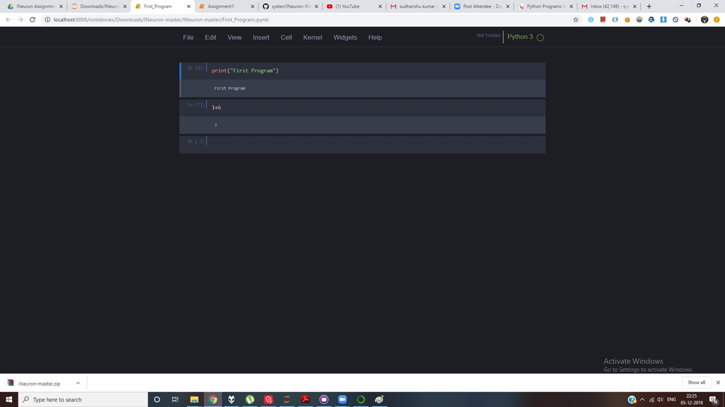

## 2) Write a program which will find all such numbers which are divisible by 7 but are not a multiple of 5, between 2000 and 3200 (both included). The numbers obtained should be printed in a comma-separated sequence on a single line.

```python
for i in range(2000,3201):
    if (i%7)==0:
        if (i%5)!=0:
            print(i,",",end='\t')
```

```
2002 ,	2009 ,	2016 ,	2023 ,	2037 ,	2044 ,	2051 ,	2058 ,	2072 ,	2079 ,	2086 ,	2093 ,	2107 ,	2114 ,	2121 ,	2128 ,	2142 ,	2149 ,	2156 ,	2163 ,	2177 ,	2184 ,	2191 ,	2198 ,	2212 ,	2219 ,	2226 ,	2233 ,	2247 ,	2254 ,	2261 ,	2268 ,	2282 ,	2289 ,	2296 ,	2303 ,	2317 ,	2324 ,	2331 ,	2338 ,	2352 ,	2359 ,	2366 ,…
```

## 3) Write a Python program to accept the user's first and last name and then getting them printed in the the reverse order with a space between first name and last name.

```python
FirstName = input("Please enter your first name ")
LastName = input("Please enter your Last name ")
print(LastName +' '+ FirstName)
```

```
Please enter your first name Santosh
Please enter your Last name Yeleri
Yeleri Santosh
```

## 4) Write a Python program to find the volume of a sphere with diameter 12 cm. Formula: V=4/3 *π* r 3

```python
pi = 3.14
r = 6
## Because radius r is diameter/2)
V = 4/3*pi*r**3
print("Volume of sphere is :",V)
```

```
Volume of sphere is : 904.3199999999999
```

## Task 2:

## 1) Write a program which accepts a sequence of comma-separated numbers from console and generate a list.

```python
Input_Values = input("Input sequence of numbers ")
l = Input_Values.split(",")
print(l)
```

```
Input sequence of numbers 8,5,9,5,6,7.
['8', '5', '9', '5', '6', '7.']
```

## 2.Create the below pattern using nested for loop in Python.

```python
for i in range (0, 5):
    for j in range(0, i + 1):
        print("*", end=' ')
    print("\r")

for i in range (5, 0, -1):
    for j in range(0, i -1):
        print("*", end=' ')
    print("\r")
```

[output not shown]

## 3) Write a Python program to reverse a word after accepting the input from the user.

```python
input_str = input("Enter text to reverse ")
s1 = ''
for c in input_str:
    s1 = c + s1
print(s1)
```

```
Enter text to reverse santosh
hsotnas
```

## 4) Write a Python Program to print the given string in the format specified in the sample output.

WE, THE PEOPLE OF INDIA, having solemnly resolved to constitute India into aSOVEREIGN, SOCIALIST, SECULAR, DEMOCRATIC REPUBLIC and to secure to all its citizens

```python
input_text = input("Enter any text ")
print(input_text)
```

```
Enter any text WE, THE PEOPLE OF INDIA, having solemnly resolved to constitute India into a SOVEREIGN, SOCIALIST, SECULAR, DEMOCRATIC REPUBLIC and to secure to all its citizens
WE, THE PEOPLE OF INDIA, having solemnly resolved to constitute India into a SOVEREIGN, SOCIALIST, SECULAR, DEMOCRATIC REPUBLIC and to secure to all its citizens
```

```python
print(input_text[:25:]+"\n"+input_text[25:87:]+"\n"+input_text[87:128:]+"\n"+input_text[128::])
##print(input_text[91::])
```

```
WE, THE PEOPLE OF INDIA,
having solemnly resolved to constitute India into a SOVEREIGN,
 SOCIALIST, SECULAR, DEMOCRATIC REPUBLIC
and to secure to all its citizens
```